# Logistic Regression

## 4. Which error metric(s)—accuracy, sensitivity, or specificity rate—matter the most for this prediction problem (i.e. identify customers who are most likely to accept a loan offer)?

### The specificity rate would be the most helpful in this situation because it is so high we can determine almost all of the negative cases that will decline our offer.

### In fact, we know that around 883 customers will decline our offer so we can work with them for a better offer.

### It is also worth mentioning that this model is very accurate (95.3%) which means that the model is correctly predicting the binary outcomes of acceptance.

## ROC Curve

### I attached the ROC Curveto help evaluate the model's overall performance, as well as to choose an appropriate classification threshold based on the desired balance between sensitivity (true positive rate) and specificity (true negative rate).

```python
from sklearn.metrics import roc_curve, roc_auc_score, auc

# Calculate ROC curve and AUC score
y_pred_prob = logreg.predict_proba(x_test)[::,1]
fpr, tpr, thresholds = roc_curve(y_test, y_pred_prob)
roc_auc = roc_auc_score(y_test, y_pred_prob)
```

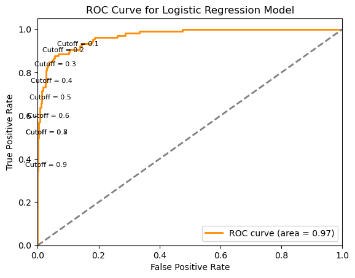

```python
# Plot ROC curve
plt.plot(fpr, tpr, color='darkorange', lw=2, label='ROC curve (area = %0.2f)' % roc_auc)
plt.plot([0, 1], [0, 1], color='gray', lw=2, linestyle='--')
plt.xlim([0.0, 1.0])
plt.ylim([0.0, 1.05])
plt.xlabel('False Positive Rate')
plt.ylabel('True Positive Rate')
plt.title('ROC Curve for Logistic Regression Model')
plt.legend(loc="lower right")

# Label each cutoff
cutoffs = [0.1,0.2,0.3,0.4,0.5,0.6, 0.7,0.8, 0.9]
for cutoff in cutoffs:
    idx = np.argmin(np.abs(thresholds - cutoff))
    plt.annotate(f"Cutoff = {cutoff}", (fpr[idx], tpr[idx]), textcoords="offset points", xytext=(10,5), ha='center', fontsize=8)

plt.show()
```

# 5. Do you feel confident presenting your trained logistic regression model as a solution to better customer targeting to the marketing department? Why or why not?